# Project3_JessicaSinha.R

2025-07-19

## Importing the MIMIC IV Clinical Demo dataset

## Data Quality Checks on Patients Data

## Data Quality Check on Outpatient Measurements

## Deriving Pulse Pressure

```r
# - This code calculate pulse pressure for rows where result_name is "Blood Pressure".
# - Pulse Pressure = Systolic - Diastolic.
# - sub(".*/", "", result_value)` extracts the diastolic (after the slash).
# - sub("/.*", "", result_value)` extracts the systolic (before the slash).
# - It then converts both characters to numeric and subtracts them, and assigns NA to other rows.

outpatient_measurements <- outpatient_measurements %>%
  mutate(
    pulse_pressure = case_when(
      result_name == "blood pressure" ~ as.numeric(sub("/.*", "", result_value)) -
                                         as.numeric(sub(".*/", "", result_value)),
      TRUE ~ NA_real_
    )
  )

# View a sample of calculated pulse pressure values

outpatient_measurements %>%
  filter(result_name == "blood pressure") %>%
  select(result_value, pulse_pressure) %>%
  head(5)
```

```
## # A tibble: 5 × 2
##   result_value pulse_pressure
##   <chr>                 <dbl>
## 1 110/70                   40
## 2 112/80                   32
## 3 128/84                   44
## 4 132/84                   48
## 5 138/90                   48
```

## Cardiovascular Disease Terms

## Classify diseases: Cardiovascular vs Non-Cardiovascular

```
## # A tibble: 5 × 2
##   subject_id cvd_classification
##        <dbl> <chr>
## 1   10014729 non-cardiovascular
## 2   10014729 cardiovascular
## 3   10003400 non-cardiovascular
## 4   10003400 non-cardiovascular
## 5   10003400 non-cardiovascular
```

```
## The total number of cardiovascular diseases is 85.
## The total number of non-cardiovascular diseases is 190.
```

## Summarize BMI, Height, and Weight, Pulse Pressure for Cardiovascular Diseases

```r
# Define function to summarize outpatient measurements for a classification.

Summarize0mws <- function(class_label) {

  # Filter subject_ids by classification (cardiovascular vs non-cardiovascular).

  subject_ids <- patients_data %>%
    filter(cvd_classification == class_label) %>%
    distinct(subject_id)

  # Filter outpatient data for those patients (weight,bmi,height).

  measurements <- outpatient_measurements %>%
    filter(subject_id %in% subject_ids$subject_id)

  # Define helper function inside larger function (summarize_outpatient_measurements).

  summarize_numeric <- function(data, var_name, display_name) {
    data %>%
      filter(result_name == var_name) %>%                # Keep  rows where the result_name matches the variable of interest.
      mutate(value = as.numeric(result_value)) %>%       # Convert result_value column to numeric and store as "value".

       # Calculate summary statistics for the numeric values
       summarise(
        n = sum(!is.na(value)),                          # Compute the number of observations (non-missing values).
        mean = round(mean(value, na.rm = TRUE), 1),      # Compute mean.
        median = round(median(value, na.rm = TRUE), 1),  # Compute median.
        sd = round(sd(value, na.rm = TRUE), 1),          # Compute standard deviation.
        min = round(min(value, na.rm = TRUE), 1),        # Compute minimum value.
        max = round(max(value, na.rm = TRUE), 1)         # Compute maximum value.
      ) %>%

      # Add a column to display name of the variable (e.g., "Weight (kg)").
      mutate(variable = display_name)
  }

  # Pulse pressure summary

  summary_pulse <- measurements %>%

    # Keep only rows where pulse_pressure is not missing.

    filter(!is.na(pulse_pressure)) %>%

    summarise(
      n = n(),                                                  # Count of non-missing values in the pulse pressure data.
      mean = round(mean(pulse_pressure, na.rm = TRUE), 1),      # Compute mean.
      median = round(median(pulse_pressure, na.rm = TRUE), 1),  # Compute median.
      sd = round(sd(pulse_pressure, na.rm = TRUE), 1),          # Compute standard deviation.
      min = round(min(pulse_pressure, na.rm = TRUE), 1),        # Compute minimum value.
      max = round(max(pulse_pressure, na.rm = TRUE), 1)         # Compute maximum value.
    ) %>%

    # Add a column to display name of the variable.
    mutate(variable = "Pulse Pressure")

  # Compute statistical summary for weight, bmi, and height.

  summary_weight <- summarize_numeric(measurements, "weight (lbs)", "weight (lbs)")
  summary_bmi    <- summarize_numeric(measurements, "bmi (kg/m2)", "bmi (kg/m2)")
  summary_height <- summarize_numeric(measurements, "height (inches)", "height (inches)")

  # Combine the rows.

  summary_long <- bind_rows(
    summary_weight,
    summary_bmi,
    summary_height,
    summary_pulse
  )
  # Convert into a long format.
  summary_long %>%
    pivot_longer(cols = c(n, mean, median, sd, min, max),
                 names_to = "statistic", values_to = "value") %>%
    pivot_wider(names_from = variable, values_from = value)
}

# Call the function for cardiovascular and non-cardiovascular patient groups.
cvd_summary_table <- Summarize0mws("cardiovascular")
noncvd_summary_table <- Summarize0mws("non-cardiovascular")


# Display statistical summary for cardiovascular patients.
cvd_summary_table %>%
  gt() %>%
  tab_header(
    title = "Summary Statistics: Cardiovascular Disease Patients"
  )
```

Summary Statistics: Cardiovascular Disease Patients

| statistic | weight (lbs) | bmi (kg/m2) | height (inches) | Pulse Pressure |
| --- | --- | --- | --- | --- |
| n | 720.0 | 595.0 | 315.0 | 626.0 |
| mean | 176.3 | 28.3 | 67.7 | 60.0 |
| median | 171.0 | 26.6 | 70.0 | 59.0 |
| sd | 46.6 | 5.3 | 4.0 | 18.3 |
| min | 92.2 | 14.6 | 60.0 | 19.0 |
| max | 296.0 | 45.2 | 73.0 | 131.0 |

```r
# Display statistical summary for non-cardiovascular patients.
noncvd_summary_table %>%
  gt() %>%
  tab_header(
    title = "Summary Statistics: Non-Cardiovascular Disease Patients"
  )
```

Summary Statistics: Non-Cardiovascular Disease Patients

| statistic | weight (lbs) | bmi (kg/m2) | height (inches) | Pulse Pressure |
| --- | --- | --- | --- | --- |
| n | 868.0 | 737.0 | 355.0 | 820.0 |
| mean | 174.6 | 28.0 | 67.2 | 57.9 |
| median | 169.3 | 26.8 | 66.5 | 56.0 |
| sd | 42.9 | 5.0 | 4.0 | 17.4 |
| min | 88.0 | 14.6 | 58.0 | 8.0 |
| max | 296.0 | 45.2 | 73.0 | 131.0 |

## Hypothesis Testing

```r
# CLINICAL QUESTION

# Does higher pulse pressure increase the likelihood of being classified
# as a cardiovascular disease patient?

# Null Hypothesis (H₀):
# There is no significant difference in pulse pressure between
# cardiovascular and non-cardiovascular patients.
# (μ₁ = μ₂)

# Alternative Hypothesis (H₁):
# There is a significant difference in pulse pressure between the two groups.
# (μ₁ ≠ μ₂)

# ASSUMPTIONS:

# Independence of Observations:
# - The pulse pressure measurements for each patient are assumed to be independent
# Normality of Distribution
# - The distribution of pulse pressure within each group should be approximately normal
# - given the large sample sizes in both groups (n > 30), the Central Limit Theorem applies
# Homogeneity of Variances:
# - The variability of pulse pressure should be similar between groups

# CHECK FOR VARTIACNE

# Null Hypothesis (H₀):
# The variances of pulse pressure are equal between cardiovascular and
# non-cardiovascular patients.
# (σ₁² = σ₂²)

# Alternative Hypothesis (H₁):
# The variances of pulse pressure are not equal between the two groups.
# (σ₁² ≠ σ₂²)

# Get subject_ids for cardiovascular patients.
cvd_subject_ids <- patients_data %>%
  filter(cvd_classification == "cardiovascular") %>%
  distinct(subject_id)

# Get subject_ids for non-cardiovascular patients.
noncvd_subject_ids <- patients_data %>%
  filter(cvd_classification == "non-cardiovascular") %>%
  distinct(subject_id)

# Extract pulse pressure values for cardiovascular patients.
cvd_pp <- outpatient_measurements %>%
  filter(subject_id %in% cvd_subject_ids$subject_id) %>%
  pull(pulse_pressure) %>%
  na.omit()

# Extract pulse pressure values for non-cardiovascular patients.
noncvd_pp <- outpatient_measurements %>%
  filter(subject_id %in% noncvd_subject_ids$subject_id) %>%
  pull(pulse_pressure) %>%
  na.omit()

# Test for equality of variances between cardiovascular and non-cardiovascular patients.
var.test(cvd_pp, noncvd_pp)
```

```
##
##  F test to compare two variances
##
## data:  cvd_pp and noncvd_pp
## F = 1.106, num df = 625, denom df = 819, p-value = 0.1778
## alternative hypothesis: true ratio of variances is not equal to 1
## 95 percent confidence interval:
##  0.9552187 1.2825671
## sample estimates:
## ratio of variances
##           1.106039
```

```r
# Result:
# F = 1.106, p-value = 0.1778

# Conclusion:
# Since the p-value is greater than 0.05, we fail to reject the null hypothesis.
# Therefore, we assume equal variances and proceed with a two-sample t-test
# using var.equal = TRUE.

# PERFORM A TWO SAMPLE T-TEST

t_test_result <- t.test(cvd_pp, noncvd_pp, var.equal = TRUE)

# View test result
t_test_result
```

```
##
##  Two Sample t-test
##
## data:  cvd_pp and noncvd_pp
## t = 2.2307, df = 1444, p-value = 0.02586
## alternative hypothesis: true difference in means is not equal to 0
## 95 percent confidence interval:
##  0.2540016 3.9578506
## sample estimates:
## mean of x mean of y
##  60.00958  57.90366
```

```r
# Reword the variable names from the t-test output for easier reading.
tidy_ttest <- tidy(t_test_result) %>%
  rename(
    `mean difference` = estimate,
    `mean (cardiovascular)` = estimate1,
    `mean (non-cardiovascular)` = estimate2,
    `t statistic` = statistic,
    `p-value` = p.value,
    `degrees of freedom` = parameter,
    `CI lower` = conf.low,
    `CI upper` = conf.high,
    `test method` = method,
    `test type` = alternative
  )

# View the t-test results in a formatted table using gt()
tidy_ttest %>%
  gt() %>%
  tab_header(
    title = "Two-Sample t-test: Pulse Pressure by Disease Classification"
  ) %>%
  fmt_number(columns = everything(), decimals = 3) %>%
  cols_align(align = "left", columns = everything())
```

Two-Sample t-test: Pulse Pressure by Disease Classification

| mean difference | mean (cardiovascular) | mean (non-cardiovascular) | t statistic | p-value | degrees of freedom | CI lower | CI upper | test method | test type |
| --- | --- | --- | --- | --- | --- | --- | --- | --- | --- |
| 2.106 | 60.010 | 57.904 | 2.231 | 0.026 | 1,444.000 | 0.254 | 3.958 | Two Sample t-test | two.sided |

```r
# Conclusion:
# The p-value from the t-test is 0.02586, which is less than the 0.05 significance level.
# Therefore, we reject the null hypothesis and conclude that there is a statistically
# significant difference in mean pulse pressure between cardiovascular and non-cardiovascular patients.
# The mean pulse pressure for cardiovascular patients is approximately 60.01 mmHg,
# compared to 57.90 mmHg in non-cardiovascular patients.
# 95% CI for the difference in means is (0.25, 3.96), which does not include 0,
# reinforcing that the difference is statistically significant.
```

## Graphical Representation

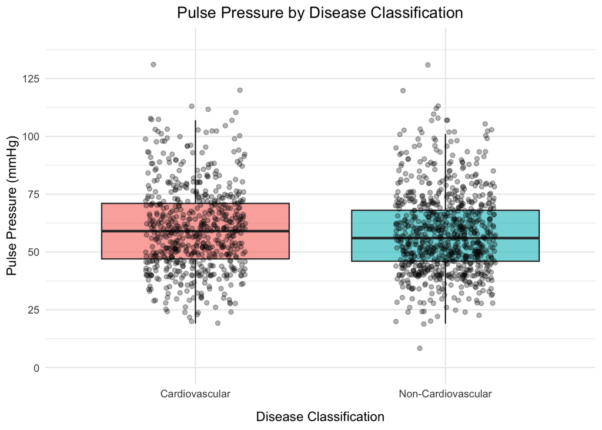

```r
# Combine pulse pressure and group labels (cardiovascular and non-cardiovascular) into one data frame.
pulse_data <- data.frame(
  pulse_pressure = c(cvd_pp, noncvd_pp),
  group = c(rep("Cardiovascular", length(cvd_pp)),
            rep("Non-Cardiovascular", length(noncvd_pp)))
)

# Create boxplot with jittered points to visualize pulse pressure by group (cardiovascular and non-cardiovascular).
ggplot(pulse_data, aes(x = group, y = pulse_pressure, fill = group)) +
  geom_boxplot(outlier.shape = NA, alpha = 0.6) +
  geom_jitter(width = 0.2, alpha = 0.3, color = "black") +
  scale_y_continuous(
    name = "Pulse Pressure (mmHg)",
    breaks = seq(0, 150, by = 25),     # Set tick marks every 25 mmHg
    limits = c(0, 140)                 # Set y-axis limits to 0 and 140
  ) +
  labs(
    title = "Pulse Pressure by Disease Classification",
    x = "Disease Classification"
  ) +
  theme_minimal() +
  theme(
    legend.position = "none",                              # Hide legend
    axis.title.x = element_text(margin = margin(t = 10)),  # Add space below x-axis label
    plot.title = element_text(hjust = 0.5)                 # Center title
  )
```

```r
# This boxplot compares the distribution of pulse pressure between patients
# with cardiovascular disease and those without. Each box represents the
# interquartile range (IQR) of pulse pressure for each group (25th to 75th percentile),
# and the horizontal line inside the box shows the median, which corresponds to the
# 50th percentile (also called the 2nd quartile). Jittered black dots represent individual
# observations, helping to visualize the spread and density of the data.
# Overall, the plot shows that patients with cardiovascular disease tend to have
# slightly higher pulse pressure compared to non-cardiovascular patients.
```

## Discussion

This project used four MIMIC-IV tables: “patients”, “diagnoses_icd”, “d_icd_diagnoses”, and “omr”. Patient demographics were linked with diagnosis codes and descriptions to identify disease types, while outpatient measurements were used to extract clinical values such as bmi, weight, blood pressure, and height. The patients were classified based on cardiovascular versus non-cardiovascular disease and this was derived by matching cleaned diagnosis descriptions against a list of cardiovascular-related terms obtained from the National Library of Medicine. Furthermore, pulse pressure was calculated from the outpatient blood pressure values by subtracting the diastolic value from the systolic value.

This data analysis explored whether there is statistically significant difference in pulse pressure between patients with cardiovascular and non-cardiovascular diseases. The null hypothesis stated that there is no difference in pulse pressure between cardiovascular and non-cardiovascular patients (μ₁ = μ₂), while the alternate hypothesis stated that there is a difference (μ₁ ≠ μ₂). To test against the null hypothesis, a two-sample t-test was conducted, and the resulting p-value was 0.026. Considering a significance level of α = 0.05, the p-value is statistically significant (0.026 < 0.05). This indicates a statistically significant difference in mean pulse pressure between the cardiovascular and non-cardiovascular patient groups. Cardiovascular patients had a higher average pulse pressure (≈60.01 mmHg) compared to non-cardiovascular patients (≈57.90 mmHg) and this difference was statistically significant.

However, this analysis has several limitations. The sample size was small, as the MIMIC-IV demo dataset includes only 100 patients and may not reflect the broader population. Additionally, the study did not adjust for key confounding variables such as patient age, gender, weight, BMI, or comorbid conditions (e.g., hypertension or diabetes), which are known to influence both pulse pressure and cardiovascular risk. A more comprehensive analysis using the full MIMIC-IV dataset and multivariate statistical methods is recommended to validate these findings.